# Chapter 4. Matplotlib绘图

可视化和绘图是数据分析中重要的任务之一，可以看作是数据分析的最后一个步骤。Python有很多附加库可以用来制作静态或动态的可视化文件：

- Matplotlib：最经典的Python 2D绘图库，以各种硬拷贝格式和跨平台的交互式环境生成出版质量级别的图形。取名源于 MATLAB+Plot+Library，绘图风格模仿MATLAB。
- Seaborn：由于Matplotlib风格有些偏古典，Python开源社区开发了Seaborn绘图模块，本质上是对Matplotlib的封装，绘图效果更符合现代人的审美观。
- Plotly：以上两个库存在一个很大的缺陷：属于静态的绘图模块，绘制出的图像是静态的，交互式效果不足。目前GitHub开源网站最火的绘图工具叫做Plotly，是一个基于JavaScript的动态绘图模块，可以实现动态交互效果。

尽管Python目前已发展出许多绘图库进行可视化，但Matplotlib的地位仍然不可撼动，其创建之初就是一个用于生成出版级质量图表的绘图包，因此我们仍然学习Matplotlib进行绘图。

## 4.1 Matplotlib入门

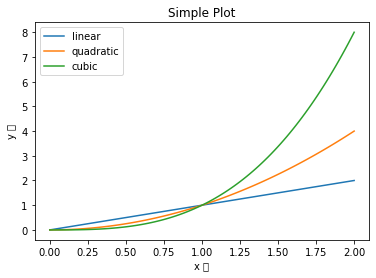

```python
# Sample with Matplotlib
import matplotlib.pyplot as plt
import numpy as np

x = np.linspace(0, 2, 100)  # linspace()函数返回100个0-2均匀分布的样本

plt.plot(x, x, label='linear')
plt.plot(x, x**2,label='quadratic')
plt.plot(x, x**3, label='cubic')

plt.title('Simple Plot')
plt.xlabel('x 轴')
plt.ylabel('y 轴')

plt.legend()
plt.show()
```

### 两个不足及解决方案

针对Matplotlib存在的不足，我们通过以下两个方法来解决。

1. 针对Matplotlib绘制的图片精度低、无法交互的问题，在导入库的同时加上如下魔术指令：`%matplotlib notebook`，即可在jupyter notebook行内形成交互式的图表。
2. 针对Matplotlib绘制的图片无法支持中文字符，在绘图时加上如下代码，指定中文字体即可：`plt.rcParams['font.sans-serif'] = ['SimHei']`，指定中文后负号无法正常显示，需再添加`plt.rcParams['axes.unicode_minus'] = False`

Mac电脑解决方案：

1. Mac中可以通过执行魔术指令：`%matplotlib`，弹出精度高、可交互对话框。
2. 先通过`matplotlib.font_manager.fontManager.ttflist`查看以安装的字体，然后使用以下两句话实现支持中文字符和显示负号： `plt.rcParams['font.sans-serif'] = ['Heiti TC']`  
   `plt.rcParams['axes.unicode_minus'] = False`

```python
import matplotlib
import matplotlib.pyplot as plt

# %matplotlib notebook  # 魔术指令
# matplotlib.font_manager.fontManager.ttflist  # 查看字体
# plt.figure(tight_layout=False,dpi=200)  # 如果只想要高精度图片而不需要交互，可使用dpi参数设置

plt.rcParams['font.sans-serif'] = ['Heiti TC']  # 设置中文字体，可以更改为'SimHei'/'DengXian'
plt.rcParams['axes.unicode_minus'] = False  # 设置成中文字体后正常显示负号
plt.tight_layout()  # 紧密布局，使中文标题和文字完整显示
```

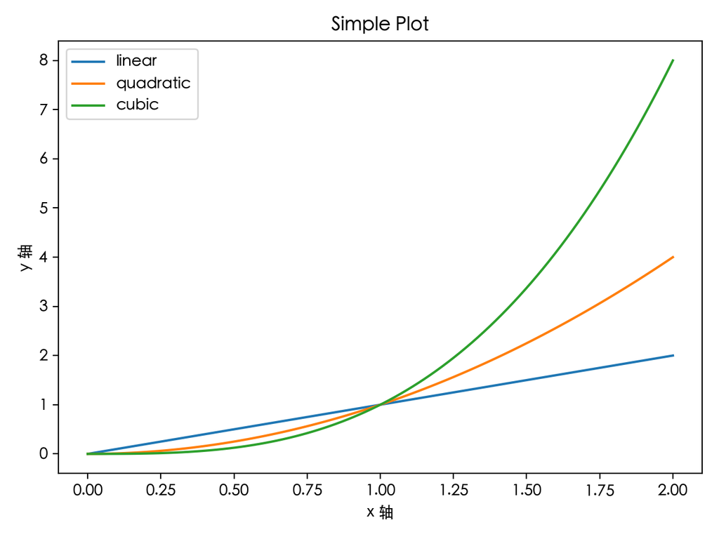

```python
# Sample with Matplotlib
%matplotlib notebook

plt.plot(x, x, label='linear')
plt.plot(x, x**2,label='quadratic')
plt.plot(x, x**3, label='cubic')

plt.title('Simple Plot')
plt.xlabel('x 轴')
plt.ylabel('y 轴')

plt.rcParams['font.sans-serif'] = ['SimHei']  # 设置中文字体，可以更改为'SimHei'/'DengXian'
plt.rcParams['axes.unicode_minus'] = False  # 设置成中文字体后正常显示负号
plt.tight_layout()  # 紧密布局，使中文标题和文字完整显示

plt.legend()
plt.show()
```

### 绘图基本流程

由此可得，Matplotlib绘制一张图片（一对轴）的流程可以总结如下：

1. 导入绘图模块（matplotlib是整个包，而matplotlib.pyplot是matplotlib中的一个模块）：`import matplotlib.pyplot as plt`，并在Jupyter notebook中执行魔术指令：`%matplotlib notebook`；
2. 使用plt调用各类函数绘制基本图形（比如主函数`plt.plot()`绘制线形图，`plt.bar()`绘制柱状图，`plt.scatter()`绘制散点图，`plt.hist()`绘制直方图等等）；
3. 使用plt调用其它函数进一步丰富图片（比如`plt.title()`设置标题，`plt.xlabel(),plt.ylabel()`设置X\Y轴标签，`plt.legend()`显示图例，`plt.annotate()`设置注释文本等等）；
4. 如果输出的文本中有中文，需要对中文字体进行指定`plt.rc("font",family='SimHei')`，指定中文后负号无法正常显示，需再添加`plt.rc('axes',unicode_minus=False)`;
5. 使用plt.show()将图片显示出来，使用plt.savefig()保存图片。

绘制的图片结构如下图所示。

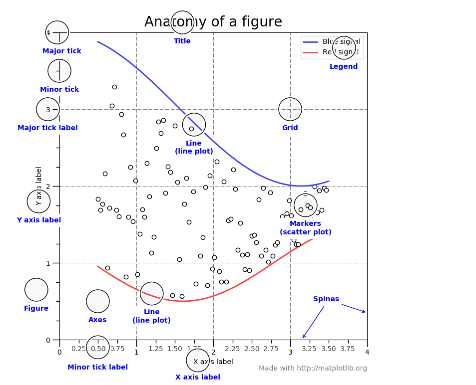

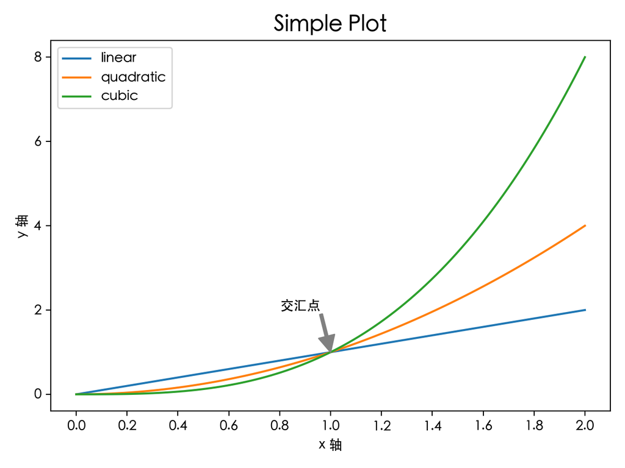

```python
# 根据上述绘图基本框架，再写一次引例并进一步细化
import numpy as np
# 绘图模块的导入惯例以及魔术指令
import matplotlib.pyplot as plt
%matplotlib notebook

x = np.linspace(0, 2, 100)

# ----------**-----以下是使用plt调用各类函数绘制基本图形-----**-----------

# 使用.plot方法绘制多条线形图，第一次调用.plot时会创建轴，随后的多次调用.plot会在相同的轴内绘制线形图
plt.plot(x, x, label='linear')
plt.plot(x, x**2,label='quadratic')
plt.plot(x, x**3, label='cubic')  # 每条线形图设置了标签label

# ----------**-----以下是使用plt调用其它函数进一步丰富图片-----**-----------

# 设置图片的标题
plt.title('Simple Plot', fontsize=16, color='black')

# 设置X/Y轴的标题
plt.xlabel('x 轴')
plt.ylabel('y 轴')

# 设置X/Y轴的刻度
plt.xticks(ticks=np.arange(0,2.2,0.2))
plt.yticks(ticks=[0,2,4,6,8])

# 设置X/Y轴的范围
# plt.xlim=[0,1]
# plt.ylim=[0,6]

# 显示图例
plt.legend()  # 将每条线形图的标签label显示出来

# 显示网格
# plt.grid()

# 添加注释（文本）
# plt.text(1, 1, '交汇点', fontsize=12)

# 添加注释（文本、箭头等）
plt.annotate(text='交汇点',   # 注释的文本
             xy=(1, 1),   # 需要注释的点位置
             xytext=(0.8, 2),  # 显示注释文本的位置
             arrowprops=dict(color='grey',width=2))  # 设置注释箭头

# 设置中文字体
plt.rcParams['font.sans-serif'] = ['SimHei']  # 设置中文字体，可以更改为'SimHei'/'DengXian'
plt.rcParams['axes.unicode_minus'] = False  # 设置成中文字体后正常显示负号
plt.tight_layout()  # 紧密布局，使中文标题和文字完整显示

# 输出图形
plt.show()

# 保存图形
plt.savefig('Simple Plot.jpg')
```

## 4.2 使用pandas对象绘制基本图形

Pandas对象（Series和DataFrame）可以直接使用`.plot()`方法调用画图方法，允许不遵循上述标准流程。

### 4.2.1 线形图 Line

线形图\折线图\时间序列图往往是针对时间序列所作统计图，因此折线图的横轴往往时间（顺序不能乱），纵轴是某一时刻的指标取值。将每个时间点上采集到的数据标在图上，相邻的两个点用直线连接起来就成了折线图。折线图一般用来看趋势、看周期、看突发事件并且做预测。

如果线形图的横轴是数值（连续型变量）而非时间，则可用来解读横轴和纵轴两个变量之间的关系。

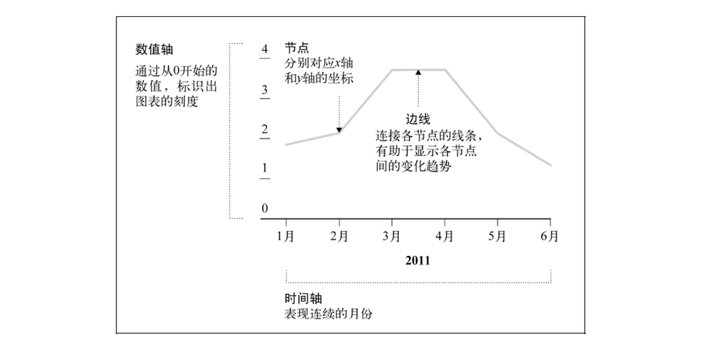

#### 例1-1 Series对象调用`plot()`函数

```python
# 生成一个Series对象
import pandas as pd
import numpy as np
N = 50
s = pd.Series(np.random.randn(N))
s.head()
```

```
0    1.732484
1   -0.070588
2   -0.330755
3    1.759332
4    2.006653
dtype: float64
```

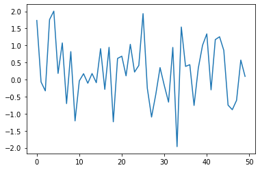

```python
# Pandas对象可以直接调用画图方法，如Series.plot()，index作为x轴数据，values作为y轴数据
s.plot()
```

注意：上述语句即使不导入`matplotlib`也可以绘制，只是存在之前描述的两个不足，如需解决不足，仍然可以通过导入`matplotlib`及其相关语句来解决。

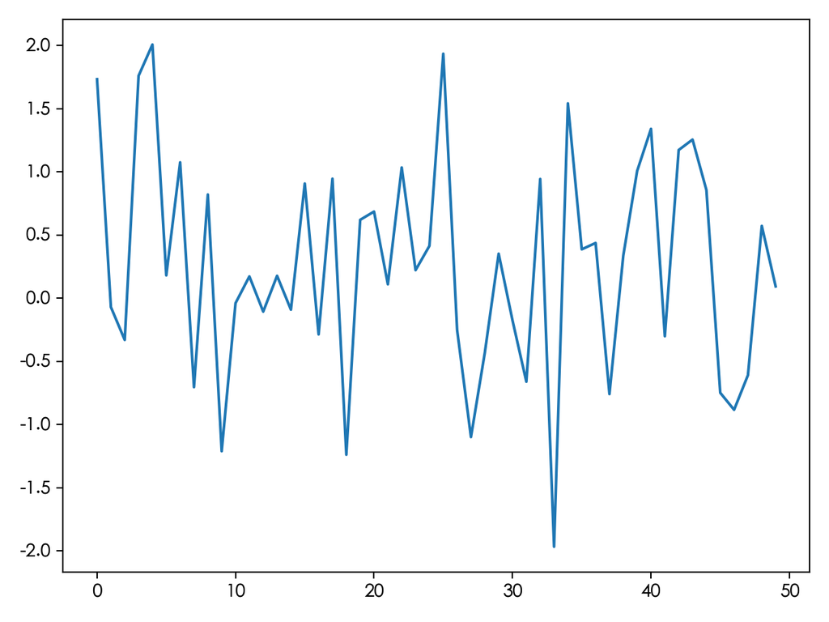

```python
# 增加配置语句，启动内核后执行一次即可
import matplotlib.pyplot as plt
%matplotlib notebook

s.plot()

plt.rcParams['font.sans-serif'] = ['SimHei']  # 设置中文字体，可以更改为'SimHei'/'DengXian'
plt.rcParams['axes.unicode_minus'] = False  # 设置成中文字体后正常显示负号
plt.tight_layout()  # 紧密布局，使中文标题和文字完整显示
```

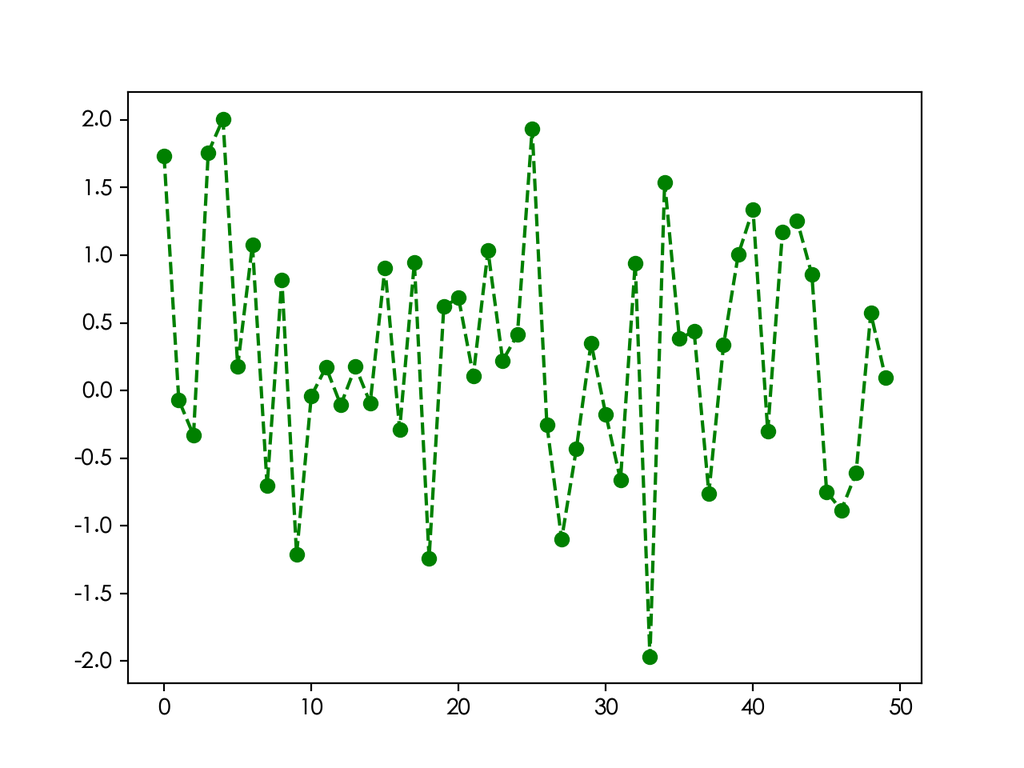

```python
# 主函数plot接收带有x和y的数组以及一些可选的字符串缩写参数来指定颜色color、标记marker和线类型linestyle
s.plot(style='go--')  # 颜色为green，标记为o，线类型为--
# s.plot(color='green',marker='o',linestyle='dashed')  # 同等写法

# s.plot(style='r+')  # 颜色为red，标记为+，线类型为空
# s.plot(color='red',marker='+',linestyle='')  # 同等写法
```

#### 例1-2 DataFrame对象调用`plot()`函数

```python
# 生成一个DataFrame对象
import pandas as pd
import numpy as np
N = 100
df = pd.DataFrame([np.random.randn(N),np.random.randn(N)+5,np.random.randn(N)-5]).T
df.columns = ['Plot1','Plot2','Plot3']
df.head()
```

|  | Plot1 | Plot2 | Plot3 |
| --- | --- | --- | --- |
| 0 | 0.025245 | 5.227870 | -5.197295 |
| 1 | -0.938502 | 4.279469 | -4.823941 |
| 2 | 1.245087 | 5.449350 | -3.613138 |
| 3 | -0.324069 | 6.022035 | -4.231747 |
| 4 | -0.465912 | 3.912823 | -5.082177 |

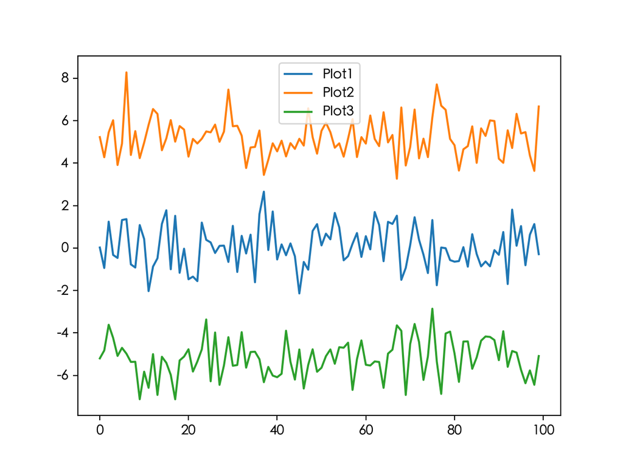

```python
# Pandas对象可以直接调用画图方法，如DataFrame.plot()，
# index作为x轴数据，values作为y轴数据，columns作为多个图形的label
df.plot()
```

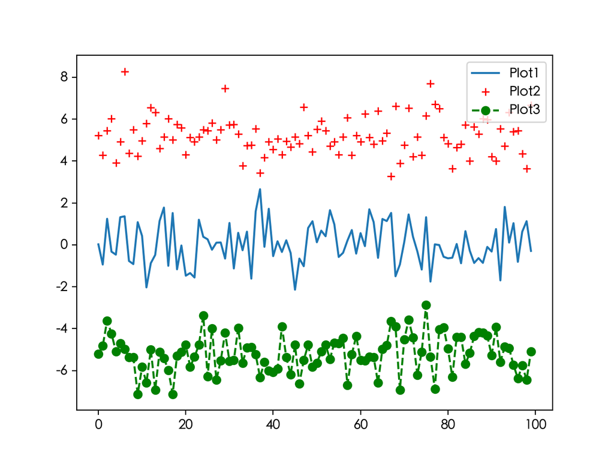

```python
# 对style参数传递列表或字典进行多样化设置
df.plot(style=['','r+','go--'])
plt.legend(loc=1)  # 将label显示出来并置于右上角
```

### 时间序列分析

```python
# 导入数据文件'超市.xls'，分析每天的销售额
import pandas as pd
df = pd.read_excel('超市.xls', sheet_name='订单', index_col='行 ID')  # 读取数据
data = df.groupby('订单日期')['销售额'].sum() # 按订单日期分组，返回每一天的销售额和利润之和
data
```

```
订单日期
2015-01-01    11926.250
2015-01-02    32997.160
2015-01-03    17063.172
2015-01-04     7793.184
2015-01-05     9312.184
                ...
2018-12-25     2454.648
2018-12-26    14559.160
2018-12-28     3936.912
2018-12-29    32578.588
2018-12-30    29277.668
Name: 销售额, Length: 1239, dtype: float64
```

```python
# 索引和切片
data['2018']  # 2018年的记录
data['2018-02']  # 2018年2月的记录
data['2018-12-01':'2018-12-15']  # 切片
```

```
订单日期
2018-12-01    12384.680
2018-12-02     2229.304
2018-12-03     5676.244
2018-12-04    48955.564
2018-12-05     4650.100
2018-12-07    19255.712
2018-12-08     7850.528
2018-12-09    13185.676
2018-12-10    27484.660
2018-12-11    14491.498
2018-12-12    10353.000
2018-12-14    30329.656
2018-12-15    67945.472
Name: 销售额, dtype: float64
```

**重采样 resample**

上面的操作中，对日期进行groupby分组聚合后，时间戳是每天（D），如果想要将其转换为每月（M），可以通过重新采样来实现。重新采样是指将时间序列从一个频率转换为另一个频率的过程。将更高频率的数据聚合到低频率被称为向下采样，反之则称为向上采样。

时间序列数据的聚合可以看作是groupby的特殊用例，被称为重采样。 Pandas对象配有`resample()`方法，与`groupby()`方法类似，调用时需要对日期时间数据分组，之后再调用聚合函数。

```python
# 重新采样 Resample
data = data['2018'].resample('M',kind='period').sum()  # 按月进行重新采样，传递kind参数以时间区间返回
data
```

```
订单日期
2018-01    222862.829
2018-02    291814.068
2018-03    399711.781
2018-04    335531.357
2018-05    637673.162
2018-06    565523.427
2018-07    340308.682
2018-08    596338.806
2018-09    503469.855
2018-10    581870.177
2018-11    468822.543
2018-12    544539.100
Freq: M, Name: 销售额, dtype: float64
```

#### 练习1. 绘制2018年12月每天销售额和利润的时间序列图

导入数据文件'超市.xls'，数据分析得到2018年12月每天的销售额和利润，再进行绘图。

```python
# 数据分析
import pandas as pd
df = pd.read_excel('超市.xls', sheet_name='订单', index_col='行 ID')
data = df.groupby('订单日期')[['销售额','利润']].sum()
data = data.loc['2018-12']
data  # 返回DataFrame对象
```

| 订单日期 | 销售额 | 利润 |
| --- | --- | --- |
| 2018-12-01 | 12384.680 | 3026.800 |
| 2018-12-02 | 2229.304 | -149.016 |
| 2018-12-03 | 5676.244 | 713.384 |
| 2018-12-04 | 48955.564 | 15586.984 |
| 2018-12-05 | 4650.100 | 537.460 |
| 2018-12-07 | 19255.712 | 554.652 |
| 2018-12-08 | 7850.528 | 1658.188 |
| 2018-12-09 | 13185.676 | 2294.096 |
| 2018-12-10 | 27484.660 | 6095.880 |
| 2018-12-11 | 14491.498 | 3970.498 |
| 2018-12-12 | 10353.000 | 4011.840 |
| 2018-12-14 | 30329.656 | -392.084 |
| 2018-12-15 | 67945.472 | 17257.772 |
| 2018-12-16 | 30721.810 | -5312.090 |
| 2018-12-17 | 24825.696 | 5394.396 |
| 2018-12-18 | 17503.752 | 1215.032 |
| 2018-12-19 | 3689.952 | 158.032 |
| 2018-12-21 | 29249.052 | 5643.932 |
| 2018-12-22 | 37007.124 | 3732.764 |
| 2018-12-23 | 14877.632 | 2424.632 |
| 2018-12-24 | 39065.012 | -166.208 |
| 2018-12-25 | 2454.648 | -519.512 |
| 2018-12-26 | 14559.160 | -2258.900 |
| 2018-12-28 | 3936.912 | 1185.492 |
| 2018-12-29 | 32578.588 | 7282.128 |
| 2018-12-30 | 29277.668 | 610.288 |

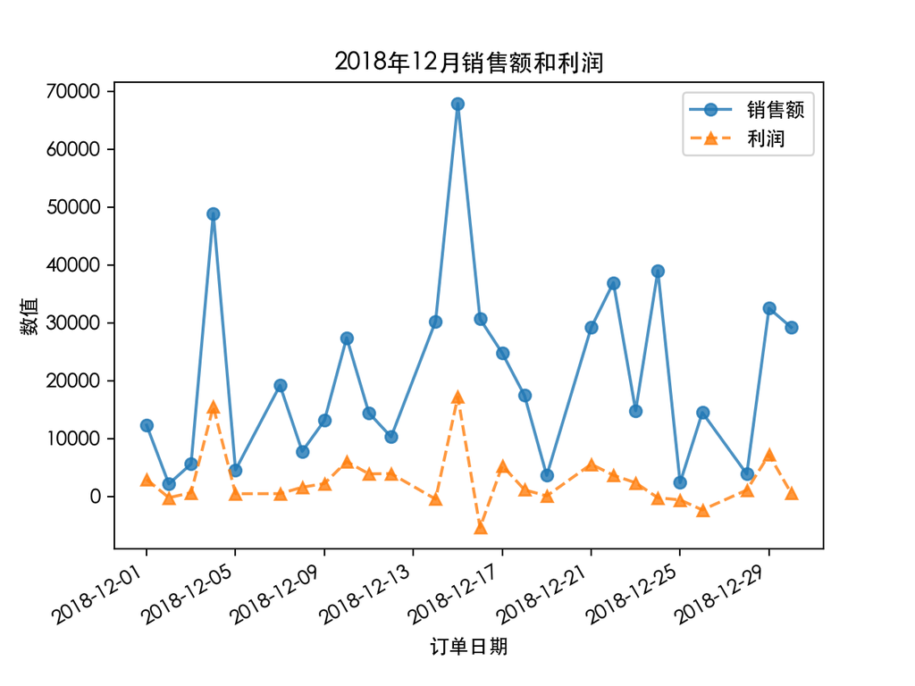

```python
# 绘制时间序列图
import matplotlib.pyplot as plt
%matplotlib notebook

data.plot(
    style=['o-','^--'],
    alpha=0.8,
)

plt.title('2018年12月销售额和利润')
plt.ylabel('数值')

plt.rcParams['font.sans-serif'] = ['SimHei']  # 设置中文字体，可以更改为'SimHei'/'DengXian'
plt.rcParams['axes.unicode_minus'] = False  # 设置成中文字体后正常显示负号
plt.tight_layout()  # 紧密布局，使中文标题和文字完整显示

plt.show()
```

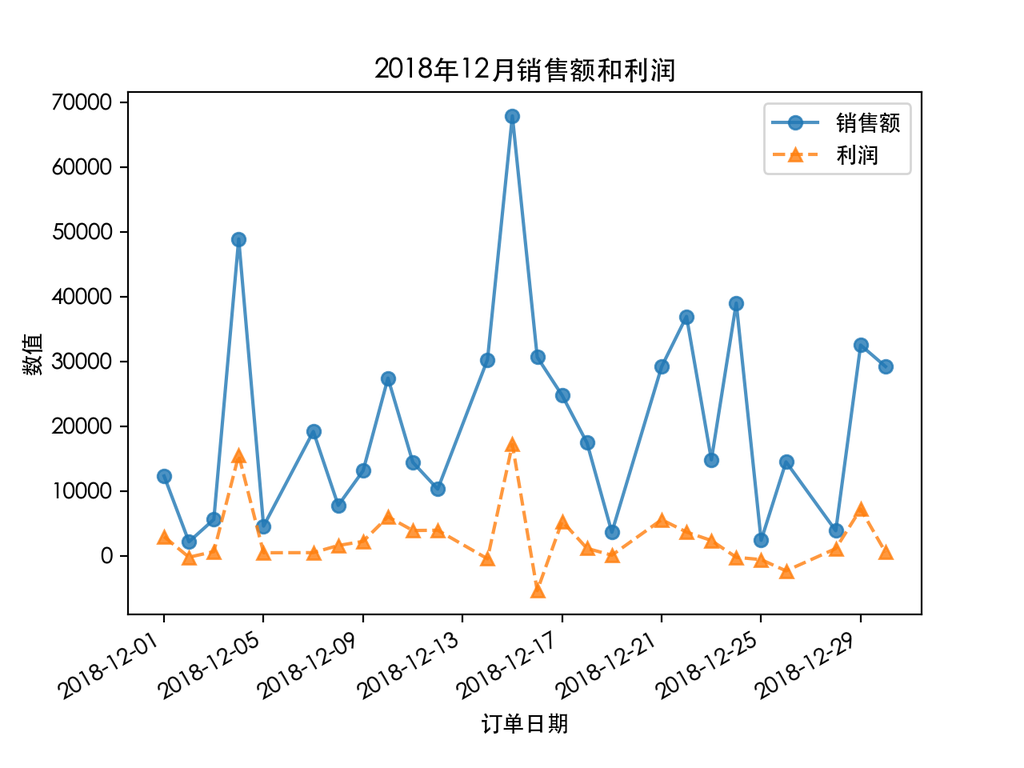

```python
# 另一种写法
data.plot(
    style=['o-','^--'],
    alpha=0.8,
    title='2018年12月销售额和利润',
    ylabel='数值'
)
```

#### 练习2. 绘制2018年每月销售额时间序列图

导入数据文件'超市.xls'，数据分析得到2018年每个月的销售额，再进行绘图。

```python
# 数据分析
import pandas as pd
df = pd.read_excel('超市.xls', sheet_name='订单', index_col='行 ID')
data = df.groupby('订单日期')['销售额'].sum()
data = data['2018']
data = data.resample('M',kind='period').sum()  # 按月进行重新采样，传递kind参数以时间区间返回
data  # 返回一个Series对象
```

```
订单日期
2018-01    222862.829
2018-02    291814.068
2018-03    399711.781
2018-04    335531.357
2018-05    637673.162
2018-06    565523.427
2018-07    340308.682
2018-08    596338.806
2018-09    503469.855
2018-10    581870.177
2018-11    468822.543
2018-12    544539.100
Freq: M, Name: 销售额, dtype: float64
```

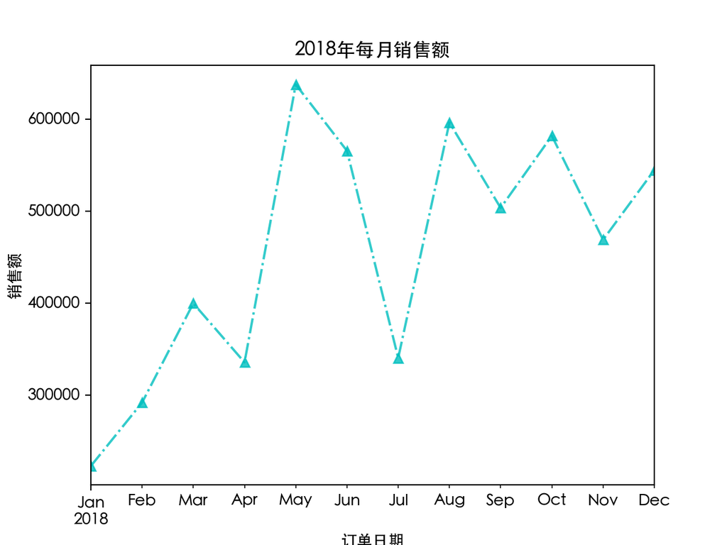

```python
# 绘制时间序列图
data.plot(
    style='c^-.',
    alpha=0.8,
    title='2018年每月销售额',
    ylabel='销售额'
)
```

#### 练习3. 绘制2018年不同产品类别的每月销售额的时间序列图

导入数据文件'超市.xls'，数据分析得到2018年不同产品类别的每个月销售额，再进行绘图。

```python
# 数据分析
import pandas as pd
df = pd.read_excel('超市.xls', sheet_name='订单', index_col='行 ID')
# data = df[df['订单日期'].array.year==2018]
data = df.groupby(['订单日期','类别'])['销售额'].sum()  # 返回一个MultiIndex的Series对象
data = data.unstack()  # unstack（拆堆）：将行中的数据透视到列（index --> columns）
data = data.loc['2018']  # DataFrame对象的行索引
data = data.resample('M',kind='period').sum()  # 按月进行重新采样，传递kind参数以时间区间返回
data  # 返回一个DataFrame对象
```

| 类别 订单日期 | 办公用品 | 家具 | 技术 |
| --- | --- | --- | --- |
| 2018-01 | 93013.004 | 57794.065 | 72055.760 |
| 2018-02 | 103612.264 | 105159.152 | 83042.652 |
| 2018-03 | 74204.872 | 189553.133 | 135953.776 |
| 2018-04 | 127448.440 | 127647.625 | 80435.292 |
| 2018-05 | 199304.364 | 192803.674 | 245565.124 |
| 2018-06 | 173380.844 | 202455.603 | 189686.980 |
| 2018-07 | 67670.456 | 118898.122 | 153740.104 |
| 2018-08 | 180607.924 | 228681.558 | 187049.324 |
| 2018-09 | 143776.612 | 219038.799 | 140654.444 |
| 2018-10 | 170600.668 | 222196.261 | 189073.248 |
| 2018-11 | 137695.404 | 142531.879 | 188595.260 |
| 2018-12 | 204151.696 | 185287.788 | 155099.616 |

```python
# 另一种数据分析方法
# data = df[df['订单日期'].array.year==2018]
data = df.pivot_table(index=['订单日期'],columns=['类别'],
                      values=['销售额'], aggfunc='sum')
data = data.loc['2018']  # DataFrame对象的行索引
data = data.resample('M',kind='period').sum()  # 重采样resample
data  # 返回一个DataFrame对象
```

| 类别 订单日期 | 销售额 办公用品 | 销售额 家具 | 销售额 技术 |
| --- | --- | --- | --- |
| 2018-01 | 93013.004 | 57794.065 | 72055.760 |
| 2018-02 | 103612.264 | 105159.152 | 83042.652 |
| 2018-03 | 74204.872 | 189553.133 | 135953.776 |
| 2018-04 | 127448.440 | 127647.625 | 80435.292 |
| 2018-05 | 199304.364 | 192803.674 | 245565.124 |
| 2018-06 | 173380.844 | 202455.603 | 189686.980 |
| 2018-07 | 67670.456 | 118898.122 | 153740.104 |
| 2018-08 | 180607.924 | 228681.558 | 187049.324 |
| 2018-09 | 143776.612 | 219038.799 | 140654.444 |
| 2018-10 | 170600.668 | 222196.261 | 189073.248 |
| 2018-11 | 137695.404 | 142531.879 | 188595.260 |
| 2018-12 | 204151.696 | 185287.788 | 155099.616 |

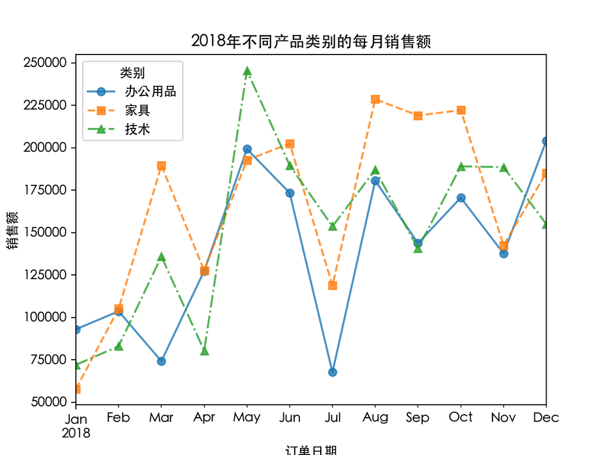

```python
# 绘制时间序列图：风格设置为圆圈实线、方块虚线、三角点线
data.plot(
    style=['o-','s--','^-.'],
    alpha=0.8,
    title='2018年不同产品类别的每月销售额',
    ylabel='销售额'
)
```

### 4.2.2 柱状图和条形图 Bar

柱状图是针对离散型数据（比如商品种类、性别等）所作的统计图。每一根柱子代表一个类别，柱子的高度是这个类别的数据统计量（计数、求和、求平均等）。若是竖着的柱子，成为柱状图；若是横着的柱子，成为条形图，本质上并没有什么区别，只是展示方向不同。

堆积柱状图和柱状图的本质是一样的，都是在展现不同类别的数据统计量。只不过简单的柱状图只涉及一个离散型变量（如商品类别），而堆积柱状图涉及两个离散型变量（如商品类别和客户细分）。因为涉及到两个离散型变量，每一个柱子可以代表一个类别，每一个堆叠代表另一个类别（子分类），那么这个子分类就需要通过其他手段（比如颜色最为常见）来进行区分。这样一来就需要一个额外的标签，标注该变量的不同类别所对应的颜色。

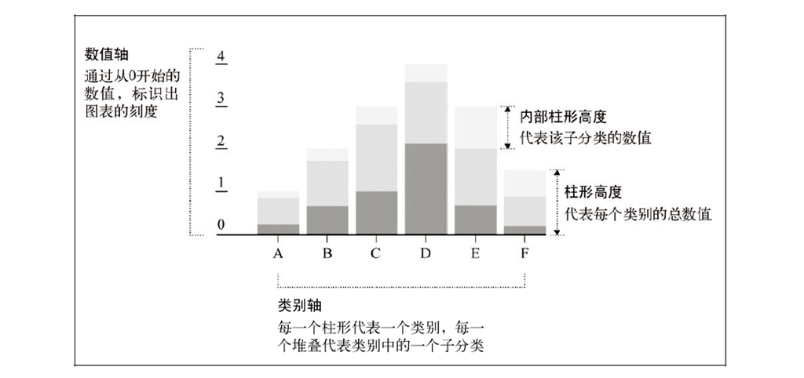

#### 例2-1 Series对象调用`plot.bar()`函数

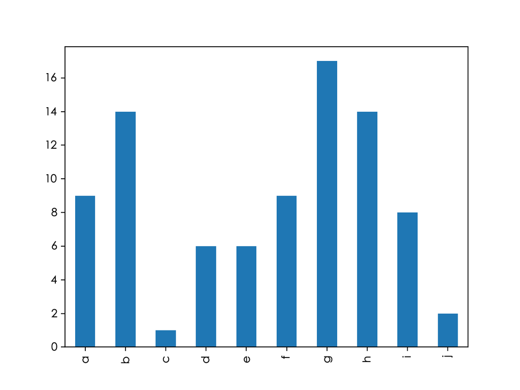

```python
import numpy as np
import pandas as pd
%matplotlib notebook

s = pd.Series(np.random.randint(20,size=10),index=list('abcdefghij'))

# s.plot(kind='bar')
s.plot.bar()
```

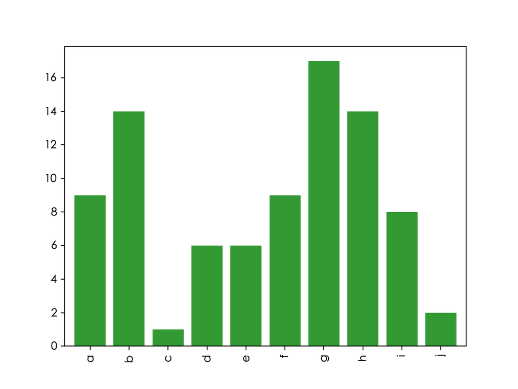

```python
# 延伸1：设置柱形的颜色和宽度
s.plot.bar(
    color='green', # 设置颜色为green
    alpha=0.8,  # 设置不透明度为0.8
    width=0.8  # 设置柱形宽度为0.8
)
```

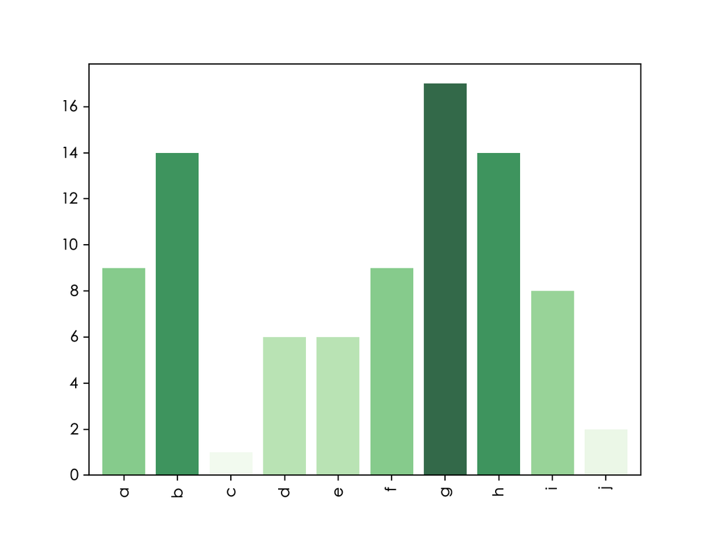

```python
# 延伸2：调用matplotlib中内置的colormaps，使颜色随值的大小而变化
# cmap颜色参考：https://matplotlib.org/tutorials/colors/colormaps.html#sphx-glr-tutorials-colors-colormaps-py
s.plot.bar(
    color=plt.get_cmap('Greens')(s/max(s)),
    alpha=0.8,
    width=0.8
)
```

#### 例2-2 DataFrame对象调用`plot.bar()`函数

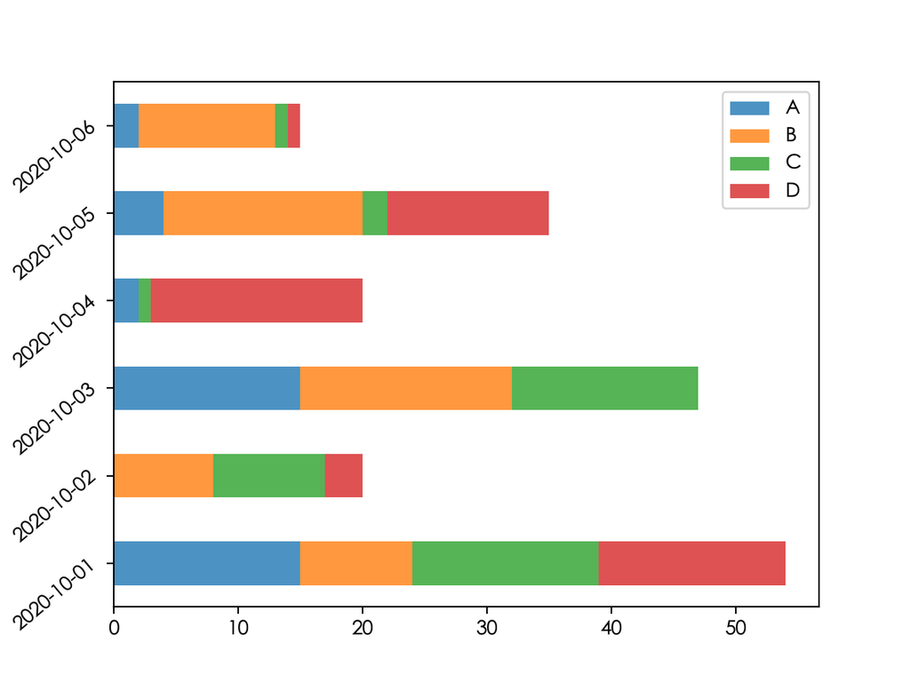

```python
import numpy as np
import pandas as pd
import matplotlib.pyplot as plt
%matplotlib notebook

data=pd.DataFrame(np.random.randint(20,size=(6,4)),
                  index=pd.date_range('20201001',periods=6).date,
                  columns=list('ABCD'))

# data.plot.bar()
data.plot.barh(
    stacked=True,  # 默认为group分组，设置为堆叠
    alpha=0.8, # 设置不透明度为0.8
    rot=40  # 设置label旋转角度
)
```

#### 练习4. 绘制商品子类别销售额的柱状图

导入数据文件'超市.xls'，数据分析得到每个商品子类别的销售额，返回的Series对象直接调用`plot.barh()`函数进行绘制。

```python
# 数据分析
import pandas as pd
df = pd.read_excel('超市.xls', sheet_name='订单', index_col='行 ID')
data = df.groupby('子类别')['销售额'].sum()
data  # 返回Series对象
```

```
子类别
书架     2310821.100
信封      288266.300
器具     2165430.708
复印机    1995047.880
收纳具    1166020.100
标签       97582.100
桌子      862010.429
椅子     2091674.256
用具      482315.820
用品      288818.376
电话     1802056.564
系固件     129241.728
纸张      264361.020
美术      197354.864
装订机     292697.888
设备      879102.448
配件      804746.656
Name: 销售额, dtype: float64
```

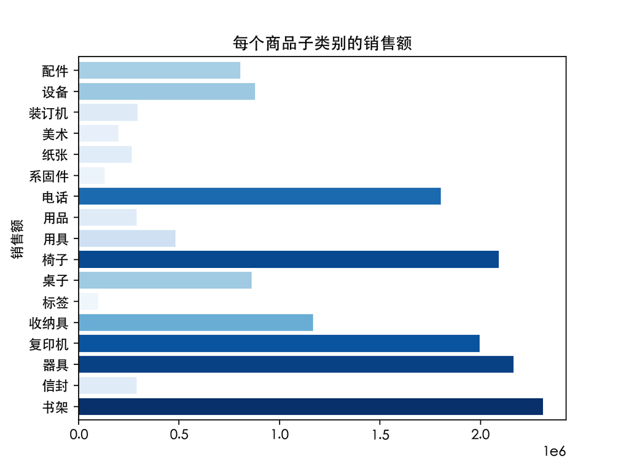

```python
# 绘制条形图：使用colormaps中'Blues'，柱形颜色随着销售额大小而变化

data.plot.barh(
    color=plt.get_cmap('Blues')(data/(max(data))),
    width=0.8,
    title='每个商品子类别的销售额',
    xlabel='销售额'
)
```

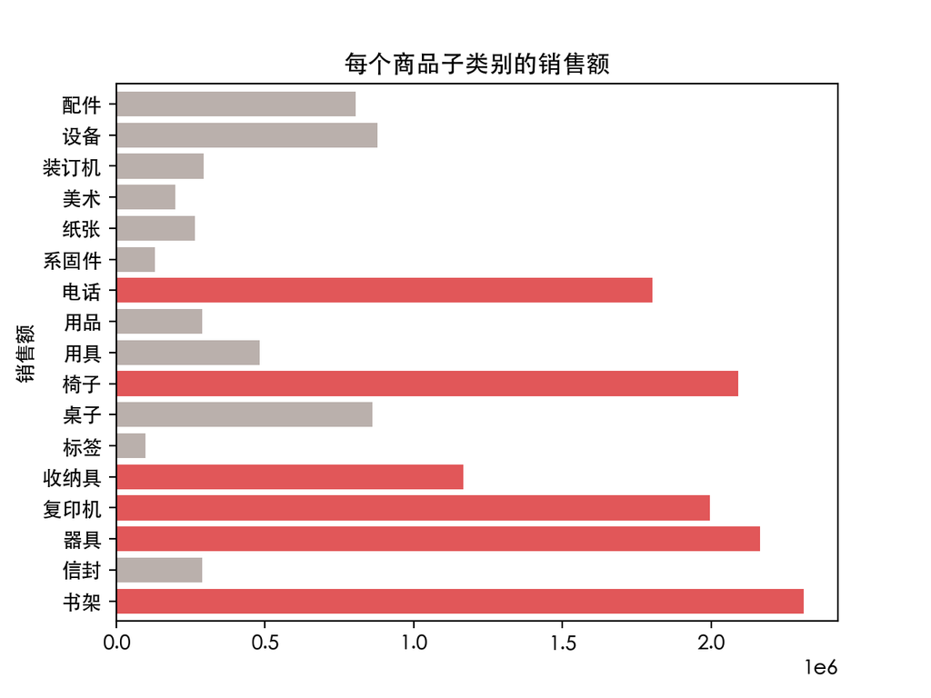

```python
# 延伸：设置一个阈值（比如10**6），销售额大于阈值的子类别用颜色'#E15759'显示，否则用颜色'#BAB0AC'显示
thred = 10**6
colors=['#BAB0AC']*data.shape[0]
for i in range(data.shape[0]):
    if data[i]>thred:
        colors[i]='#E15759'

data.plot.barh(
    color=colors,
    width=0.8,
    title='每个商品子类别的销售额',
    xlabel='销售额'
)
```

#### 练习5. 绘制商品子类别中不同客户细分销售额的堆积柱状图

导入数据文件'超市.xls'，数据分析得到每个商品子类别中不同客户细分的销售额，返回的DataFrame对象调用`plot.bar()`进行绘制。

```python
# 数据分析
import pandas as pd
df = pd.read_excel('超市.xls', sheet_name='订单', index_col='行 ID')
data = df.groupby(['细分','子类别'])['销售额'].sum()  # 返回一个MultiIndex的Series对象
data = data.unstack(level=0) # unstack（拆堆）：将行中的数据透视到列，level=0表示将0层index透视到列
data  # 返回DataFrame对象
```

| 细分 子类别 | 公司 | 小型企业 | 消费者 |
| --- | --- | --- | --- |
| 书架 | 728370.216 | 458818.948 | 1123631.936 |
| 信封 | 84092.120 | 47966.520 | 156207.660 |
| 器具 | 669985.036 | 349597.836 | 1145847.836 |
| 复印机 | 666012.144 | 343365.736 | 985670.000 |
| 收纳具 | 340742.360 | 223245.400 | 602032.340 |
| 标签 | 28648.760 | 20648.740 | 48284.600 |
| 桌子 | 322034.202 | 118465.725 | 421510.502 |
| 椅子 | 717663.114 | 378771.512 | 995239.630 |
| 用具 | 139173.104 | 90135.444 | 253007.272 |
| 用品 | 93480.660 | 49244.804 | 146092.912 |
| 电话 | 626298.596 | 303042.628 | 872715.340 |
| 系固件 | 38287.452 | 25765.992 | 65188.284 |
| 纸张 | 75666.220 | 43362.060 | 145332.740 |
| 美术 | 70228.172 | 36095.108 | 91031.584 |
| 装订机 | 86339.204 | 42047.628 | 164311.056 |
| 设备 | 223441.652 | 199466.848 | 456193.948 |
| 配件 | 249865.084 | 165745.244 | 389136.328 |

```python
# 另一种数据分析方法
import pandas as pd
df = pd.read_excel('超市.xls', sheet_name='订单', index_col='行 ID')
data = df.pivot_table(index = '子类别', columns = '细分',
                      values = '销售额', aggfunc = 'sum')
data  # 返回DataFrame对象
```

| 细分 子类别 | 公司 | 小型企业 | 消费者 |
| --- | --- | --- | --- |
| 书架 | 728370.216 | 458818.948 | 1123631.936 |
| 信封 | 84092.120 | 47966.520 | 156207.660 |
| 器具 | 669985.036 | 349597.836 | 1145847.836 |
| 复印机 | 666012.144 | 343365.736 | 985670.000 |
| 收纳具 | 340742.360 | 223245.400 | 602032.340 |
| 标签 | 28648.760 | 20648.740 | 48284.600 |
| 桌子 | 322034.202 | 118465.725 | 421510.502 |
| 椅子 | 717663.114 | 378771.512 | 995239.630 |
| 用具 | 139173.104 | 90135.444 | 253007.272 |
| 用品 | 93480.660 | 49244.804 | 146092.912 |
| 电话 | 626298.596 | 303042.628 | 872715.340 |
| 系固件 | 38287.452 | 25765.992 | 65188.284 |
| 纸张 | 75666.220 | 43362.060 | 145332.740 |
| 美术 | 70228.172 | 36095.108 | 91031.584 |
| 装订机 | 86339.204 | 42047.628 | 164311.056 |
| 设备 | 223441.652 | 199466.848 | 456193.948 |
| 配件 | 249865.084 | 165745.244 | 389136.328 |

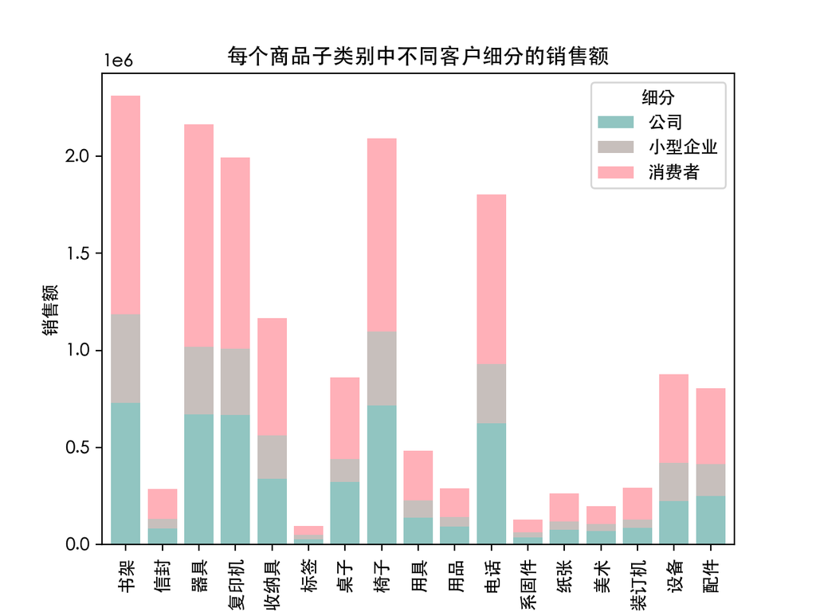

```python
# 绘制柱形图：不同客户细分类别使用不同颜色，颜色可以参考网站：https://www.materialpalette.com/colors

colors=['#76B7B2','#BAB0AC','#FF9DA7']

data.plot.bar(
    stacked=True,
    alpha=0.8,
    width=0.8,
    color=colors,
    title='每个商品子类别中不同客户细分的销售额',
    ylabel='销售额'
)
```

### 4.2.3 饼图 Pie

饼图是一种使用非常广泛的统计图，与柱状图一样，都是针对离散型数据的统计图。柱状图多用于展示频数，而饼图多用于展示频率（比例）。一个圆代表整体，然后把它切成楔形，每一个楔形代表某一个类别，所有楔形所占百分比的总和应该等于100%。饼图的块数不宜过多（将比例过少的种类归为一类，称为其它），也不宜过少（离散型变量只有两个取值时不建议画饼图），不多不少刚刚好。

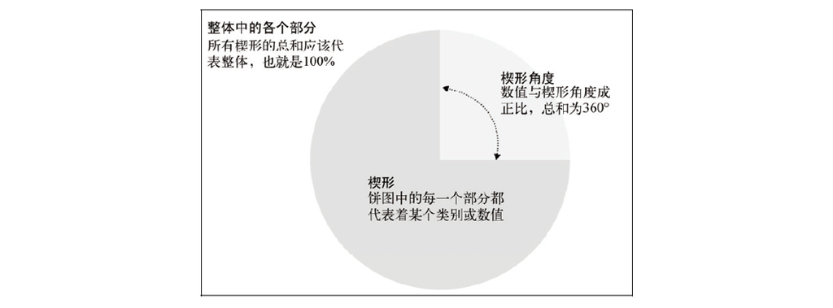

```python
# help(plt.pie)
```

#### 例3-1 Series对象调用 `plot.pie()`函数

```python
# 生成一个Series对象
import numpy as np
import pandas as pd
s = pd.Series(np.random.randint(20,size=5),index=list('abcde'))
s
```

```
a    12
b     4
c    19
d    11
e     6
dtype: int64
```

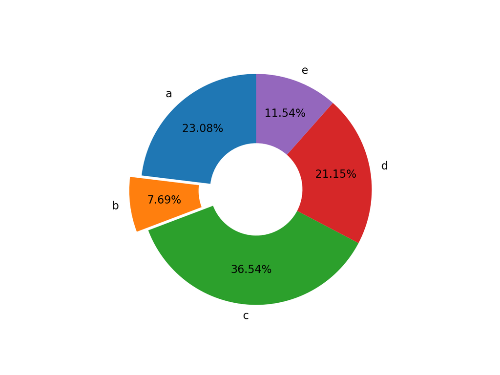

```python
# Series对象调用 plot.pie() 函数
import matplotlib.pyplot as plt
%matplotlib notebook

s.name=''  # 将Series对象的name设置为''，否则会显示None
s.plot.pie(
    autopct='%.2f%%',  # 设置百分比显示格式(两位浮点数)
    # autopct='%i%%'  # 设置百分比显示格式(整数)
    pctdistance=0.7,  # 设置百分比显示的距离，默认0.6
    labeldistance=1.1,  # 设置标签显示的距离，默认1.1
    explode=[0,0.1,0,0,0],  # 设置某块楔形突出(传递与data长度相同的序列)
    startangle=90,  # 设置起始位置的角度
    counterclock=True,  # 设置饼图的方向，默认逆时针
    wedgeprops=dict(width=0.6)  # 设置饼图内径宽度，默认1.0，可将其变为环形饼图(Donut Chart)
)
```

#### 练习6. 绘制不同地区销售额占比情况的饼图

导入数据文件'超市.xls'，数据分析得到每个地区的销售额，返回的Series对象直接调用`plot.pie()`进行绘制。  
并将占比最小地区突出显示，并在合适的位置注释出销售额总量。

```python
# 数据分析
import pandas as pd
df = pd.read_excel('超市.xls', sheet_name='订单', index_col='行 ID')
data = df.groupby('地区')['销售额'].sum()
data
```

```
地区
东北    2711223.389
中南    4147884.013
华东    4692464.994
华北    2447301.017
西北     815550.316
西南    1303124.508
Name: 销售额, dtype: float64
```

```python
# 求销售额总额
# df['销售额'].sum()
data.sum()
```

```
16117548.236999998
```

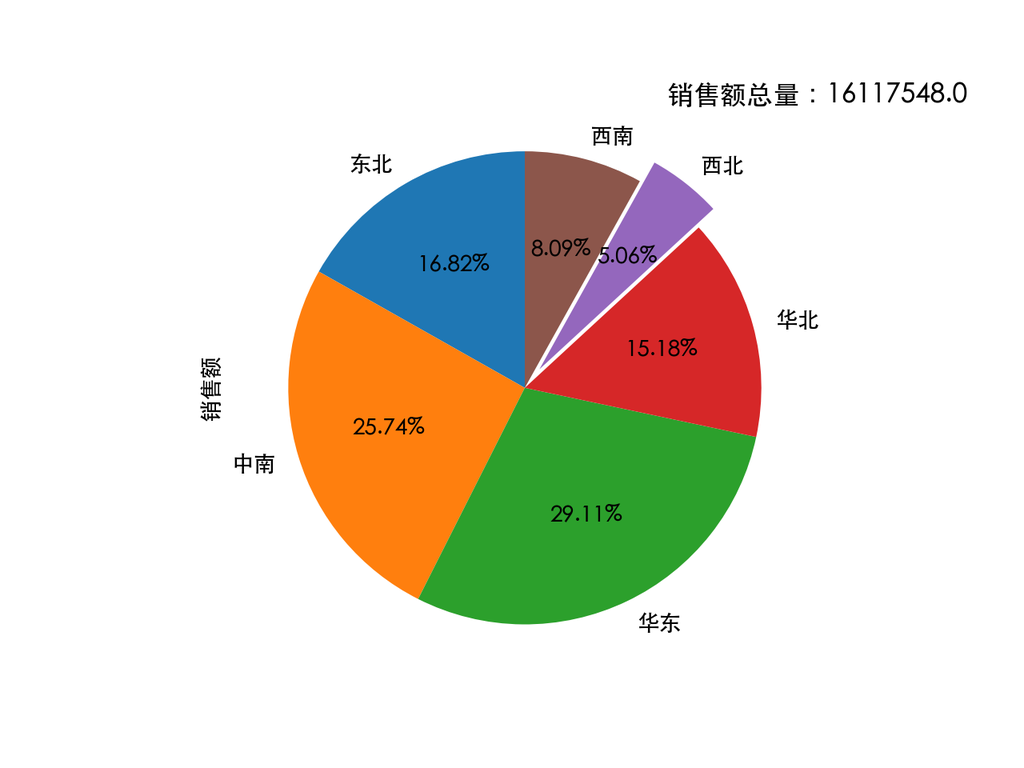

```python
# 绘制饼图：将销售额最低的扇区突出显示，并在合适位置添加注释文本

ls=[0.] *data.shape[0]  # 创建一个值为0，长度与data相等的列表ls
ls[data.argmin()]=0.1  # 获取data中最小值的位置索引，将ls中同等位置的值设置为0.1

data.plot.pie(
    autopct='%.2f%%',
    explode=ls,  # 将ls传递给explode，最小值突出显示
    startangle=90,  # 将起始位置设置为90度处
)

# 添加注释文本
plt.text(0.6,1.2,s='销售额总量：'+str(np.rint(data.sum())),fontsize=12)
```

#### 练习7. 绘制办公用品各子类别销售额占比情况的饼图

导入数据文件'超市.xls'，数据分析得到办公用品各子类别的销售额，返回的Series对象直接调用`plot.pie()`进行绘制。  
由于子类别较多，将销售额最低的4个子类别合并为"其它"，并突出显示。

```python
# 数据分析
import pandas as pd
df = pd.read_excel('超市.xls', sheet_name='订单', index_col='行 ID')
data = df[df['类别']=='办公用品']  # 筛选办公用品类别
data = data.groupby('子类别')['销售额'].sum()  # 根据子类别分组，得到每个子类别销售总额
data0 = pd.Series(data.sort_values()[:4].sum(),index=['其它'])  # 将销售额最低的四个子类别销量求和，并转化为一个Series对象赋值给data0
data1 = data.sort_values()[4:]  # 将其余子类别切片赋值给data1
data = pd.concat([data0,data1]).sort_index()  # 使用concat()函数将data0和data1沿0轴堆叠
data.name = '办公用品各子类别销售额'  # 设置Series对象的name属性，作为饼图的标题
data
```

```
信封      288266.300
其它      688539.712
器具     2165430.708
收纳具    1166020.100
用品      288818.376
装订机     292697.888
Name: 办公用品各子类别销售额, dtype: float64
```

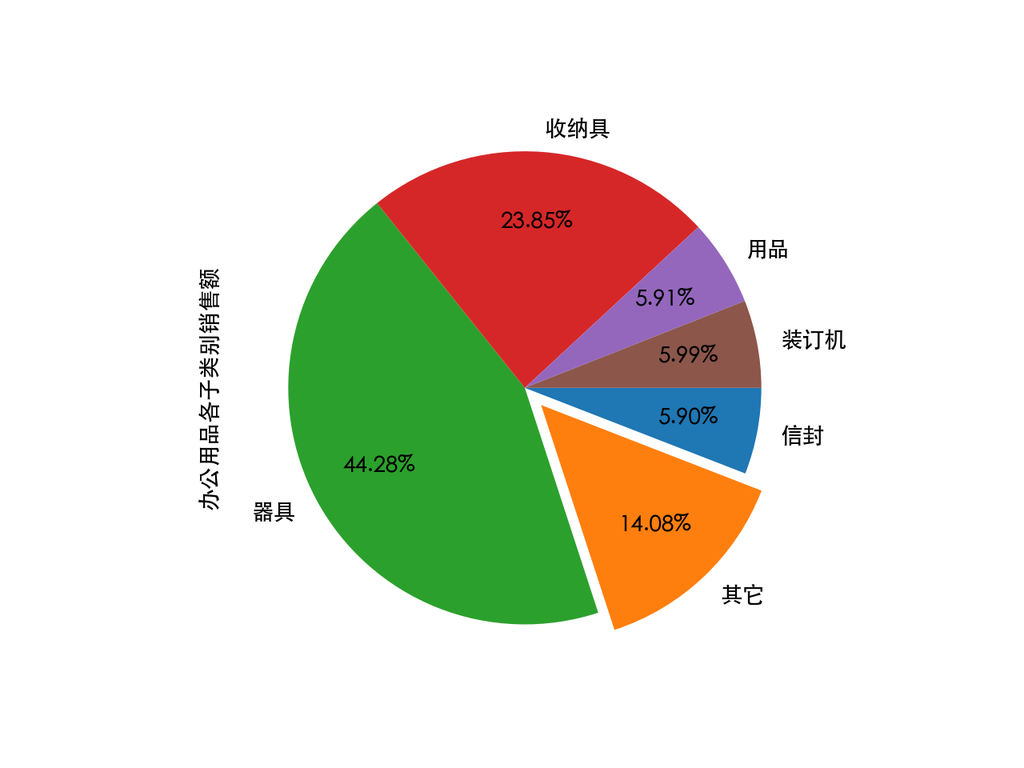

```python
# 绘制饼图
data.plot.pie(
    autopct='%.2f%%',  # 百分比显示两位浮点数
    pctdistance=0.7,  # 设置百分比显示的距离0.7
    explode=[0,0.1,0,0,0,0],  # 突出显示"其它"
    counterclock=False,  # 设置饼图的方向为顺时针
)
```